# Public perception of climate change

Robin K. S. Hankin

2019-05-16

This short document analyses the climate change dataset originally presented in the hyperdirichlet R package[^1] but using the hyper2 package instead. Lay perception of climate change is a complex and interesting process[^2] here we assess the engagement of non-experts by the use of “icons” (this word is standard in this context. An icon is a “representative symbol”) that illustrate different impacts of climate change.

Here we analyse results of one experiment[^3], in which subjects were presented with a set of icons of climate change and asked to identify which of them they find most concerning. Six icons were used: PB [polar bears, which face extinction through loss of ice floe hunting grounds], NB [the Norfolk Broads, which flood due to intense rainfall events], L [London flooding, as a result of sea level rise], THC [the thermo-haline circulation, which may slow or stop as a result of anthropogenic modification of the water cycle], OA [oceanic acidification as a result of anthropogenic emissions of ${\mathrm C}{\mathrm O}_2$], and WAIS [the West Antarctic Ice Sheet, which is rapidly calving as a result of climate change].

Methodological constraints dictated that each respondent could be presented with a maximum of four icons. The R idiom below (dataset `icons` in the package) shows the experimental results.

```r
M <- matrix(c(
    5 , 3 , NA,  4, NA,   3,
    3 , NA,  5,  8, NA,   2,
    NA,  4,  9,  2, NA,   1,
    10,  3, NA,  3,  4,  NA,
    4 , NA,  5,  6,  3,  NA,
    NA,  4,  3,  1,  3,  NA,
    5 ,  1, NA, NA,  1,   2,
    5 , NA,  1, NA,  1,   1,
    NA,  9,  7, NA,  2,   0)
  , byrow=TRUE,ncol=6)
colnames(M) <- c("NB","L","PB","THC","OA","WAIS")
M
```

```
##       NB  L PB THC OA WAIS
##  [1,]  5  3 NA   4 NA    3
##  [2,]  3 NA  5   8 NA    2
##  [3,] NA  4  9   2 NA    1
##  [4,] 10  3 NA   3  4   NA
##  [5,]  4 NA  5   6  3   NA
##  [6,] NA  4  3   1  3   NA
##  [7,]  5  1 NA  NA  1    2
##  [8,]  5 NA  1  NA  1    1
##  [9,] NA  9  7  NA  2    0
```

(M is called `icons_matrix` in the package). Each row of `M` corresponds to a particular cue given to respondents. The first row, for example, means that a total of $5+3+4+3=15$ people were shown icons NB, L, TCH, WAIS [column names of the the non-NA entries]; 5 people chose NB as most concerning, 3 chose L, and so on. The dataset is more fully described in the hyperdirichlet package. To recreate the `icons` likelihood function in the `hyper2` package, we use the `saffy()` function:

```r
library("hyper2",quietly=TRUE)
icons <- saffy(M)
icons
```

```
## NB^32 * (NB + L + THC + OA)^-20 * (NB + L + THC + WAIS)^-15 * (NB
## + L + OA + WAIS)^-9 * (NB + PB + THC + OA)^-18 * (NB + PB + THC +
## WAIS)^-18 * (NB + PB + OA + WAIS)^-8 * L^24 * (L + PB + THC +
## OA)^-11 * (L + PB + THC + WAIS)^-16 * (L + PB + OA + WAIS)^-18 *
## PB^30 * THC^24 * OA^14 * WAIS^9
```

At this point, the `icons` object as created above is mathematically identical to `icons` object in the hyperdirichlet package (and indeed the hyper2 package), but the terms might appear in a different order.

## Analysis of the icons dataset

The first step is to find the maximum likelihood estimate for the `icons` likelihood:

```r
mic <- maxp(icons)
mic
```

```
##         NB          L         PB        THC         OA       WAIS
## 0.25230411 0.17364433 0.22458188 0.17011281 0.11068604 0.06867083
```

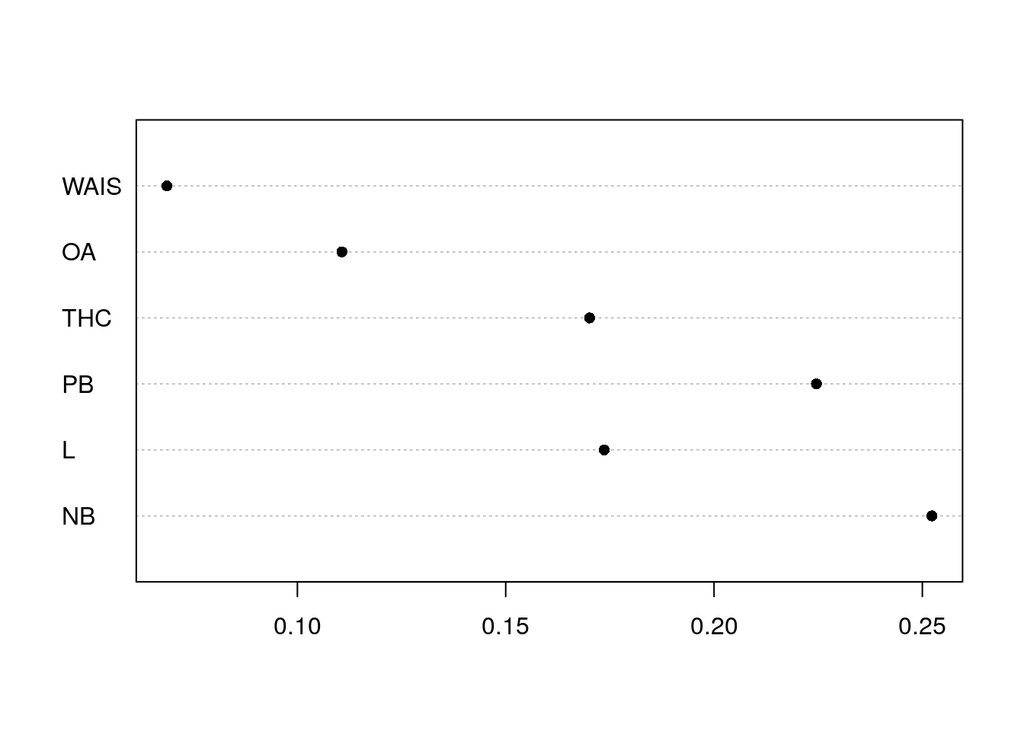

```r
dotchart(mic,pch=16)
```

We also need the log-likelihood at an unconstrained maximum:

```r
L1 <- loglik(icons,indep(mic))
L1
```

```
## [1] -174.9974
```

Agreeing to 4 decimal places with the value given in the hyperdirichlet package.

The next step is to assess a number of hypotheses concerning the relative sizes of $p_1$ through $p_6$.

## Hypothesis 1: $p_1\geqslant 1/6$

Following the analysis in Hankin 2010, we first observe that NB [the Norfolk Broads] is the largest-probability icon (as expected on theoretical grounds by O’Neill). This would suggest that $p_1$ is large, in some sense. Consider the hypothesis that $p_1\leqslant 1/6$ and to that end perform a constrained optimization, with (active) constraint that $p_1\leqslant 1/6$. This is most easily done by imposing additional constraints to the `maxp()` function via the `fcm` and `fcv` arguments:

```r
small <- 1e-6  #  ensure start at an interior point
maxlike_constrained <-
    maxp(icons, startp=indep(equalp(icons))-c(small,0,0,0,0),
         give=TRUE, fcm=c(-1,0,0,0,0),fcv= -1/6)
maxlike_constrained
```

```
## $par
## [1] 0.1666667 0.1916197 0.2681047 0.1835885 0.1190362
##
## $value
## [1] -177.6602
##
## $counts
## function gradient
##      763      109
##
## $convergence
## [1] 0
##
## $message
## NULL
##
## $outer.iterations
## [1] 3
##
## $barrier.value
## [1] 0.00015538
```

Note that the value of $p_1$ is equal to $1/6$: the maximum is on the boundary of the admissible region. The extra support is given by

```r
ES <- L1-maxlike_constrained$value
ES
```

```
## [1] 2.662764
```

(compare 2.608181 from the hyperdirichlet package). This exceeds Edwards’s two-units-of-support criterion; a $p$-value would be

```r
pchisq(2*ES,df=1,lower.tail=FALSE)
```

```
## [1] 0.02101524
```

both of which would indicate that we may reject that hypothesis that $p_1\leqslant 1/6$ and thereby infer $p_1>\frac{1}{6}$.

## Hypothesis 2: $p_1\geqslant\max\left(p_2,\ldots,p_6\right)$

Another constrained likelihood maximization, although this one is not possible with convex constraints. We have to compare `L1` against the maximum likelihood over the region defined by $p_1$ being greater than *at least one* of $p_2,\ldots,p_6$. The union of convex sets is not necessarily convex (think two-way Venn diagrams). As far as I can see, the only way to do it is to perform a sequence of five constrained optimizations: $p_1\leqslant p_2, p_1\leqslant p_3, p_1\leqslant p_4, p_1\leqslant p_5$. The fillup constraint would be $p_1\leqslant p_6\longrightarrow 2p_1+p_2+\ldots p_5\leqslant 1$. We then choose the largest likelihood from the five.

```r
o <- function(Ul,Cl,startp,give=FALSE){
    small <- 1e-6  #  ensure start at an interior point
    if(missing(startp)){startp <- small*(1:5)+rep(0.1,5)}
    out <- maxp(icons, startp=small*(1:5)+rep(0.1,5), give=TRUE, fcm=Ul,fcv=Cl)
    if(give){
        return(out)
    }else{
        return(out$value)
    }
}

p2max <- o(c(-1, 1, 0, 0, 0), 0)
p3max <- o(c(-1, 0, 1, 0, 0), 0)
p4max <- o(c(-1, 0, 0, 1, 0), 0)
p5max <- o(c(-1, 0, 0, 0, 1), 0)
p6max <- o(c(-2,-1,-1,-1,-1),-1)
```

(the final line is different because $p_6$ is the fillup value).

```r
likes <- c(p2max,p3max,p4max,p5max,p6max)
likes
```

```
## [1] -175.8237 -175.0836 -175.9986 -178.2043 -181.4944
```

```r
ml <- max(likes)
ml
```

```
## [1] -175.0836
```

Thus the first element of `likes` corresponds to the maximum likelihood, constrained so that $p_1\leqslant p_2$; the second element corresponds to the constraint that $p_1\leqslant p_3$, and so on. The largest likelihood is the easiest constraint to break, in this case $p_1\leqslant p_3$: this makes sense because $p_3$ has the second highest MLE after $p_1$. The extra likelihood is given by

```r
L1-ml
```

```
## [1] 0.08613913
```

(the hyperdirichlet package gives 0.0853 here, a suprisingly small discrepancy given the difficulties of optimizing over a nonconvex region). We conclude that there is no evidence for $p_1\geqslant\max\left(p_2,\ldots,p_6\right)$.

It’s worth looking at the evaluate too:

```r
o(c(-1, 1, 0, 0, 0), 0,give=TRUE)$par
```

```
## [1] 0.2120674 0.2120674 0.2302719 0.1649972 0.1121906
```

```r
o(c(-1, 0, 1, 0, 0), 0,give=TRUE)$par
```

```
## [1] 0.2377191 0.1736393 0.2377192 0.1718361 0.1100634
```

```r
o(c(-1, 0, 0, 1, 0), 0,give=TRUE)$par
```

```
## [1] 0.2109081 0.1787235 0.2230625 0.2109081 0.1071554
```

```r
o(c(-1, 0, 0, 0, 1), 0,give=TRUE)$par
```

```
## [1] 0.1809502 0.1764378 0.2285099 0.1651894 0.1809502
```

```r
o(c(-2,-1,-1,-1,-1),-1,give=TRUE)$par
```

```
## [1] 0.1585836 0.1776468 0.2326462 0.1646608 0.1078789
```

## Low frequency responses

The next hypothesis was testing the smallness of $p_5+p_6$, and we suspected that $p_5+p_6 < \frac{1}{3}$. This translates into optimizing subject to $p_5+p_6\geqslant\frac{1}{3}$, and the required constraint is $-p_1-p_2-p_3-p_4\geqslant-\frac{2}{3}$ (because $p_5+p_6=1-p_1-p_2-p_3-p_4$). Dead easy:

```r
jj <- o(c(-1,-1,-1,-1,0) , -2/3, give=TRUE,start=indep((1:6)/21))$value
jj
```

```
## [1] -182.2108
```

then the extra support is

```r
L1-jj
```

```
## [1] 7.213359
```

(compare 7.711396 in hyperdirichlet, not sure why the discrepancy is so large).

## Final example

The final example was $\max\left\{p_5,p_6\right\}\geqslant\min\left\{p_1,p_2,p_3,p_4\right\}$. This means the optimization is constrained so that *at least one* of $\left\{p_5,p_6\right\}$ exceeds *at least one* of $\left\{p_1,p_2,p_3,p_4\right\}$. So we have the union of the various possibilities:

$$\bigcup_{j\in\left\{5,6\right\}\atop k\in\left\{1,2,3,4\right\}}
\left\{\left(p_1,p_2,p_3,p_4,p_5,p_6\right)\left|\sum p_i=1,
p_j\geqslant p_k\right.\right\}$$

and of course $p_6\geqslant p_2$, say, translates to $-p_1-2p_2-p_3-p_4-p_5\geqslant -1$.

```r
start <- indep(c(small,small,small,small,0.5-2*small,0.5-2*small))
jj <- c(
   o(c(-1, 0, 0, 0, 1), 0,start=start),
   o(c( 0,-1, 0, 0, 1), 0,start=start),
   o(c( 0, 0,-1, 0, 1), 0,start=start),
   o(c( 0, 0, 0,-1, 1), 0,start=start),

   o(c(-2,-1,-1,-1,-1),-1,start=start),
   o(c(-1,-2,-1,-1,-1),-1,start=start),
   o(c(-1,-1,-2,-1,-1),-1,start=start),
   o(c(-1,-1,-1,-2,-1),-1,start=start)
   )
jj
```

```
## [1] -178.2043 -175.9429 -177.3242 -175.7738 -181.4944 -177.9784 -180.4066
## [8] -177.7537
```

```r
max(jj)
```

```
## [1] -175.7738
```

So the extra support is

```r
L1-max(jj)
```

```
## [1] 0.7763474
```

(compare hyperdirichlet which gives 3.16, not sure why the difference). We should look at the maximum value:

```r
   o(c( 0, 0, 0,-1, 1), 0,give=TRUE,start=start)
```

```
## $par
## [1] 0.2531001 0.1702956 0.2177958 0.1448582 0.1448582
##
## $value
## [1] -175.7738
##
## $counts
## function gradient
##      464       73
##
## $convergence
## [1] 0
##
## $message
## NULL
##
## $outer.iterations
## [1] 2
##
## $barrier.value
## [1] 0.0001725539
```

So the evaluate is at the boundary, for $p_4=p_5$. I have no explanation for the discrepancy between this and that in the hyperdirichlet package.

[^1]: RKS Hankin 2010. “A generalization of the Dirichlet distribution”, *Journal of Statistical Software*, 33:11
[^2]: SC Moser and L Dilling 2007. “Creating a climate for change: communicating climate change and facilitating social change”. Cambridge University Press
[^3]: S. O’Neill 2007. “An Iconic Approach to Representing Climate Change”, School of Environmental Science, University of East Anglia